# Transformation with matrices 行列で変換

ryamada

2016年12月19日

# 1 Exercises 1 $2 \times 2$行列による変換に関する以下の問に答えよ

## 1.1 Exercises 1-0

点 (2,3)が$2 \times 2$行列Mによる変換で動かなかったと言う。行列Mの4成分についてどのようなことが言えるか。

$$\begin{pmatrix}a, b\\ c, d \end{pmatrix} \begin{pmatrix}2 \\3 \end{pmatrix} = \begin{pmatrix}2 \\3 \end{pmatrix}\\
2a + 3b = 2\\
2c + 3d = 3\\
b=\frac{2-2a}{3}\\
d=\frac{3-2c}{3}$$
Any a,b,c, and d satisfying the equations above, transform (2,3) to (2,3).

```r
a <- runif(1)
b <- (2-2*a)/3
c. <- runif(1)
d <- (3-2*c.)/3
M <- matrix(c(a,b,c.,d),byrow=TRUE,2,2)
x <- c(2,3)
M %*% x
```

```
##      [,1]
## [1,]    2
## [2,]    3
```

## 1.2 Exercises 1-1

原点とは異なる点(p,q)が、Mによって不動であったと言う。行列Mの4成分について言えることは何か。

$$\begin{pmatrix}a, b\\ c, d \end{pmatrix} \begin{pmatrix}p \\q \end{pmatrix} = \begin{pmatrix}p \\q \end{pmatrix}\\
pa + qb = p\\
pc + qd = q\\$$
d は以下を満たす
$$d=\frac{q-pc}{q}$$

## 1.3 Exercises 1-2

点(2,3)がMによって点(4,6)に移動したという。 点(4,6)はどこに移動するか。

$$M \times \begin{pmatrix}2 \\3 \end{pmatrix} = \begin{pmatrix}4 \\6 \end{pmatrix}\\
M \times \begin{pmatrix}4 \\6 \end{pmatrix} = 2 \times M \times \begin{pmatrix}2 \\3 \end{pmatrix} = \begin{pmatrix}8 \\12 \end{pmatrix}\\$$
## Exercises 1-3

原点以外のすべての点が不動点でないようなMはどのようなMか。

定義から

$$Ap = p$$
ここで、
$$Ap = \lambda p$$
の式を考えるとp が A の固有値 1 の固有ベクトルになっている。 すなわち固有値 1 の固有ベクトルが存在すれば、不動点が存在する。逆に変換行列が固有値１をもたなければ不動点は存在しない。

# 2 Exercises 2

## 2.1 Exercise 2-1

ベクトル $(\cos{\theta_1},\sin{\theta_1})$と$(\cos{\theta_2},\sin{\theta_2})$とを固有ベクトルとし、そのベクトル方向の点は、そのベクトル方向に$\lambda_1,\lambda_2$倍するような行列は以下のように表される

$$M = V\begin{pmatrix}\lambda_1,0\\0,\lambda_2\end{pmatrix}V^{-1}$$
$$V =\begin{pmatrix}\cos{\theta_1},\cos{\theta_2}\\ \sin{\theta_1},\sin{\theta_2} \end{pmatrix}$$

固有値と固有ベクトルを指定し、それに対応する$2\times 2$変換行列を作成する関数を作れ

```r
mat.from.eigen <- function(theta1, theta2, lambda1, lambda2) {
  V = matrix(c(cos(theta1), cos(theta2),
               sin(theta1), sin(theta2)), 2, 2)
  S = diag(c(lambda1, lambda2))

  M = V %*% S %*% solve(V)
}

print(mat.from.eigen(2, 1, 3, 5) )
```

```
##          [,1]      [,2]
## [1,] 4.167706 0.8993804
## [2,] 1.080605 3.8322937
```

## 2.2 Exercise 2-2

点(1,0)を点(1,2)に移し、点(0,1)を点(2,4)に移す行列を作り、その行列の固有値と固有ベクトルを計算すると以下のように固有値の一つは0となる。

```r
M <- matrix(c(1,2,2,4),2,2)
M
```

```
##      [,1] [,2]
## [1,]    1    2
## [2,]    2    4
```

```r
eigen(M)
```

```
## eigen() decomposition
## $values
## [1] 5 0
##
## $vectors
##           [,1]       [,2]
## [1,] 0.4472136 -0.8944272
## [2,] 0.8944272  0.4472136
```

この行列によって、第一固有ベクトル方向の点が、その方向に5倍した点に移ることを計算して確かめよ。

```r
eigen.vec.1 <- eigen(M)[[2]][, 1]

(eigen.vec.1 %*% M) / eigen.vec.1
```

```
##      [,1] [,2]
## [1,]    5    5
```

```r
library(tidyverse)
```

```r
map(runif(10), function(x){(x * eigen.vec.1  %*% M) / (x * eigen.vec.1)})
```

```
## [[1]]
##      [,1] [,2]
## [1,]    5    5
##
## [[2]]
##      [,1] [,2]
## [1,]    5    5
##
## [[3]]
##      [,1] [,2]
## [1,]    5    5
##
## [[4]]
##      [,1] [,2]
## [1,]    5    5
##
## [[5]]
##      [,1] [,2]
## [1,]    5    5
##
## [[6]]
##      [,1] [,2]
## [1,]    5    5
##
## [[7]]
##      [,1] [,2]
## [1,]    5    5
##
## [[8]]
##      [,1] [,2]
## [1,]    5    5
##
## [[9]]
##      [,1] [,2]
## [1,]    5    5
##
## [[10]]
##      [,1] [,2]
## [1,]    5    5
```

## 2.3 Exercise 2-3

上記の行列によって、第一固有ベクトル方向以外の点がどこに移されるか計算して確かめよ。

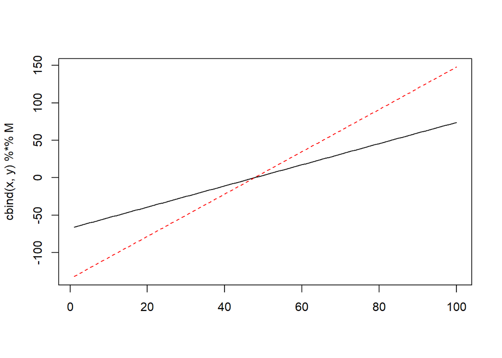

```r
x <- seq(from = -10, to = 10, length.out = 100)
y <- 3 * x + 2

matplot(cbind(x, y) %*% M, type = "l")
```

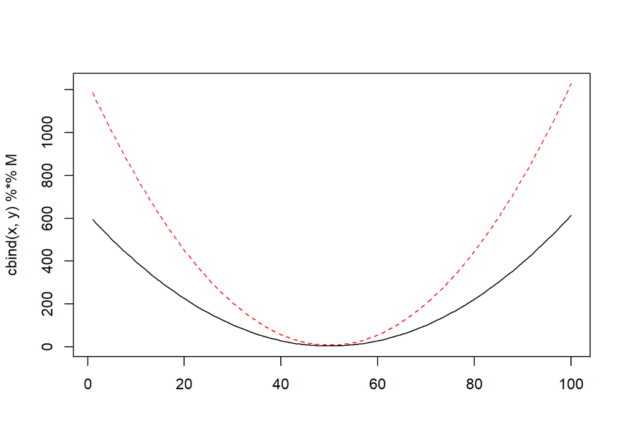

```r
x <- seq(from = -10, to = 10, length.out = 100)
y <- 3 * x^2 + 2

matplot(cbind(x, y) %*% M, type = "l")
```

## 2.4 Exercise 2-4

この行列の逆行列をRで計算するとどうなるか実行せよ。

行列Mによって点vが点uに移せるとき、逆行列Mによって点uは点vに移るはずだが、この逆行列がうまく求まらない、ということと、行列Mの変換の特徴(Exercise 2-3)との関係を述べよ。

```r
M
```

```
##      [,1] [,2]
## [1,]    1    2
## [2,]    2    4
```

```r
# solve(M)
det(M)
```

```
## [1] 0
```

行列Mによる変換によって2次元の点が直線状つまり１次元の点の集合となる。そのため情報量の損失が生じており逆方向に変換できないと解釈される。

## 2.5 Exercise 2-5

$$M = \begin{pmatrix}1,2\\3,4\end{pmatrix}$$
の固有値を求めよ。

```r
M <- matrix(c(1, 3, 2, 4), 2, 2)
eigen(M)$value
```

```
## [1]  5.3722813 -0.3722813
```

## 2.6 Exercise 2-6

$2\times 2$行列 $\begin{pmatrix}a,b\\c,d\end{pmatrix}$の固有値を行列の成分で表せ。

$$\begin{pmatrix}a-\lambda,b\\c,d-\lambda\end{pmatrix}$$

$$det\begin{pmatrix}a-\lambda,b\\c,d-\lambda\end{pmatrix} = 0\\
\lambda^2 - (a+d)\lambda + ad - bc = 0 \\
\lambda=\frac{(a+d)\pm \sqrt{(a+d)^2-4(ad-bc)}}{2}$$
## Exercise 2-7

Exercise 2-6の結果を踏まえ、M[1,1]=1、M[1,2]=1であって、固有値が複素数になるような行列Mを作成せよ。

$$(1+d)^2 - 4(d-c) < 0 \\
d^2 - 2d + 1 + 4c < 0 \\
c < \frac{d^2 - 2d + 1}{-4}$$

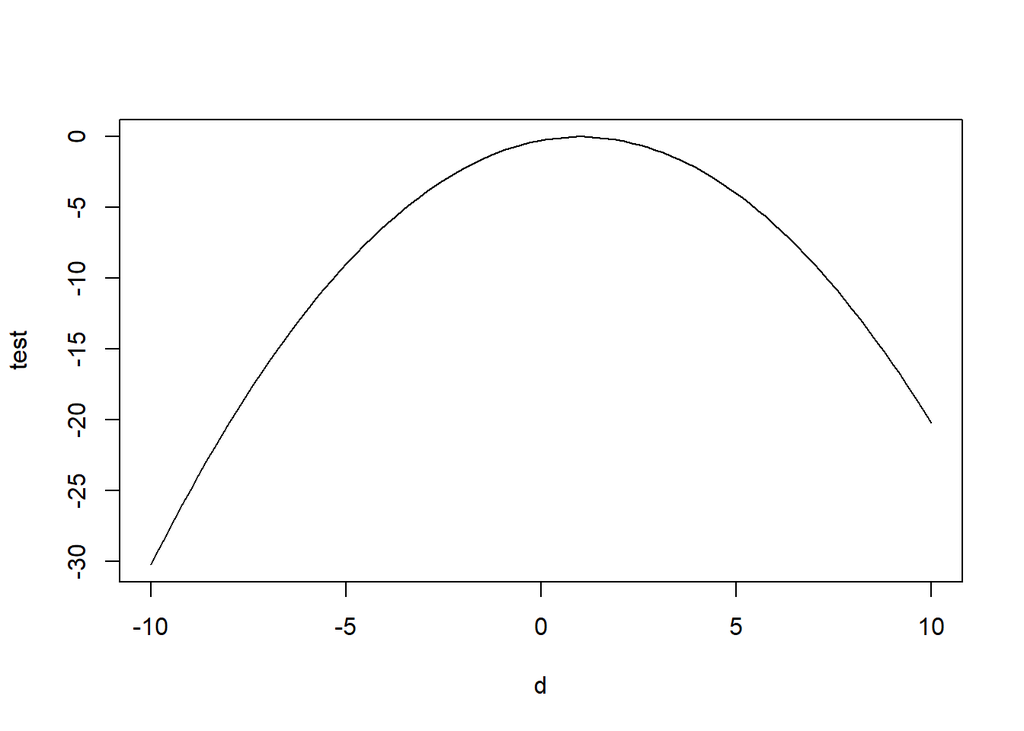

```r
d = seq(-10, 10, length.out = 100)
test = (d ^2 -2 * d + 1) / (-4)
plot(d, test, type = "l")
```

```r
M <- matrix(c(1, -1, 1, -1), 2, 2)
eigen(M)
```

```
## eigen() decomposition
## $values
## [1] -3.25177e-17+1.570092e-16i -3.25177e-17-1.570092e-16i
##
## $vectors
##               [,1]          [,2]
## [1,]  0.7071068+0i  0.7071068+0i
## [2,] -0.7071068+0i -0.7071068-0i
```

## 2.7 Exercise 2-8

行列の冪乗を用いることで、実数列{t}について$M^t$をある点に作用させたときの移動先の座標を求めることができる。

$2\times 2$行列について、異なる２つの0ではない実数固有値を持つ場合、１つの固有値が0ではない実数であり、もう一つの固有値が0である場合、２つの固有値が複素数の場合のそれぞれについて、移動先の点列を描け。

```r
mat.from.eigen <- function(theta1, theta2, lambda1, lambda2) {
  V = matrix(c(cos(theta1), cos(theta2),
               sin(theta1), sin(theta2)), 2, 2)
  S = diag(c(lambda1, lambda2))

  M = V %*% S %*% solve(V)
}

M_2R_eigen <- mat.from.eigen(0.3, 0.8, 1, 0.5)
M_1R_eigen <- mat.from.eigen(0.3, 0.8, 1, 0)
M_C_eigen <- mat.from.eigen(0.5, 1,
                            complex(real = 0, imaginary = 1),
                            complex(real = 1, imaginary = 2))


x <- seq(-3,3,by=1)
y <- seq(-3,3,by=0.01)
x. <- numeric(length(x)^2)
y. <- numeric(length(y)^2)
grid <- rbind(expand.grid(x,y),expand.grid(y,x))

plot(grid,pch=20,cex=0.1,xlim=c(-25,25),ylim=c(-25,25))
```

[output not shown]

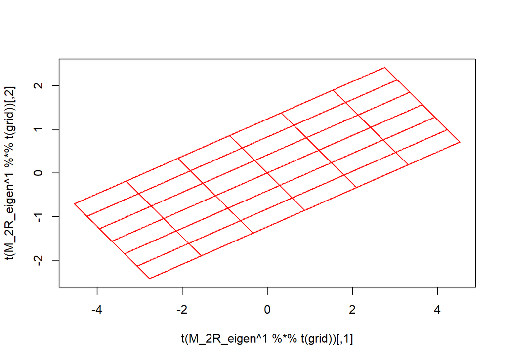

```r
plot(t(M_2R_eigen^1 %*% t(grid)), pch=20, cex=0.1, col = 2)
```

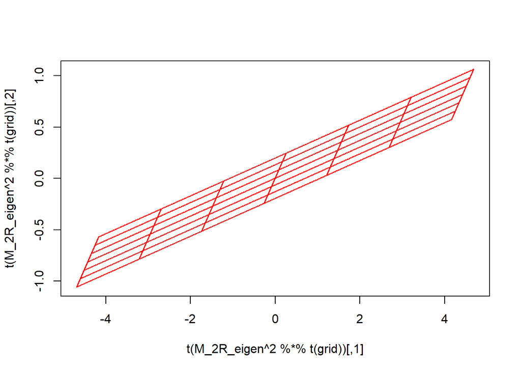

```r
plot(t(M_2R_eigen^2 %*% t(grid)), pch=20, cex=0.1, col = 2)
```

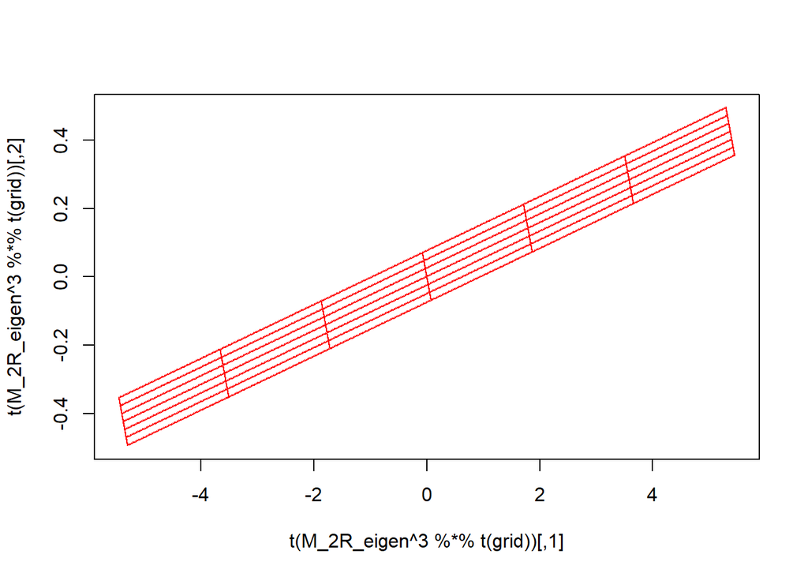

```r
plot(t(M_2R_eigen^3 %*% t(grid)), pch=20, cex=0.1, col = 2)
```

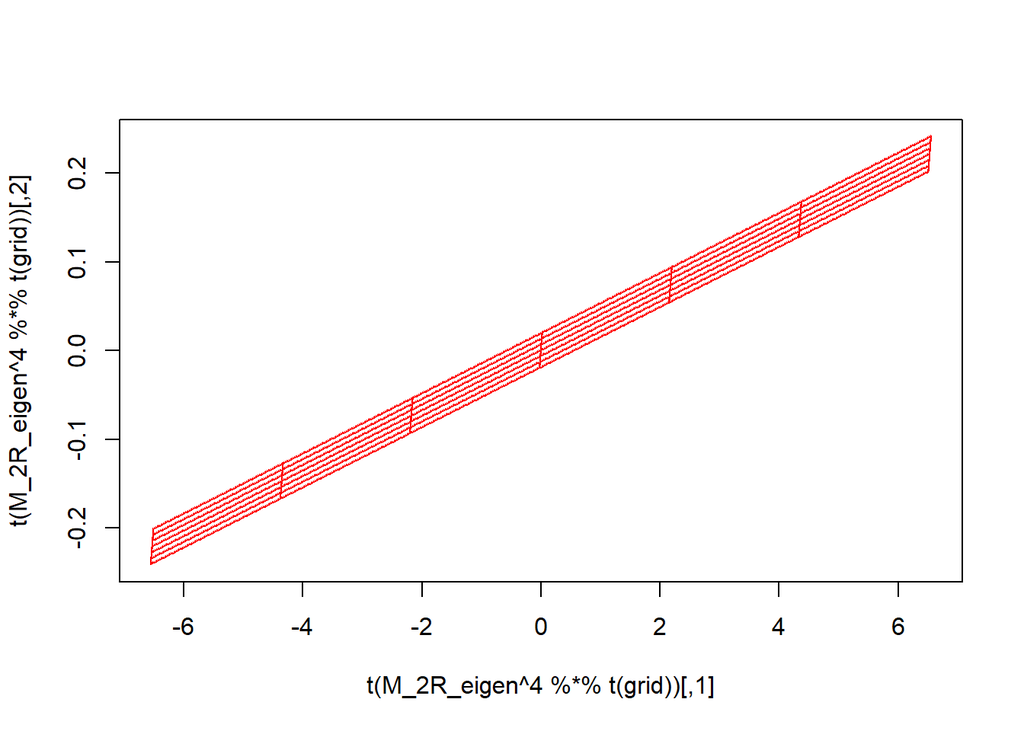

```r
plot(t(M_2R_eigen^4 %*% t(grid)), pch=20, cex=0.1, col = 2)
```

```r
plot(grid,pch=20,cex=0.1,xlim=c(-25,25),ylim=c(-25,25))
```

[output not shown]

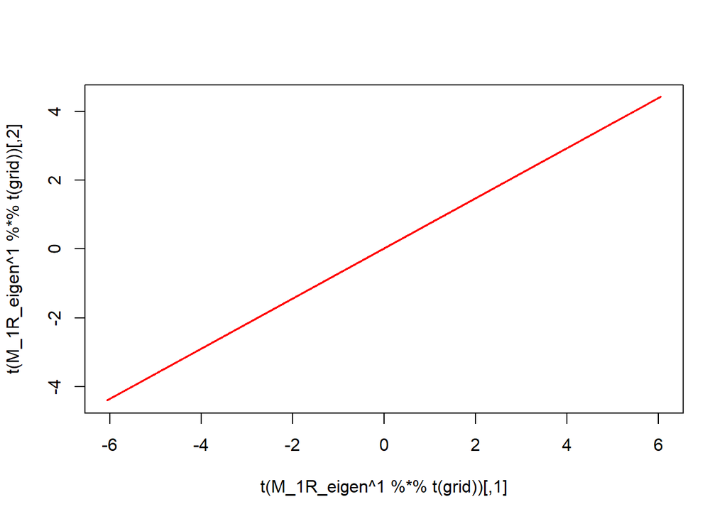

```r
plot(t(M_1R_eigen^1 %*% t(grid)), pch=20, cex=0.1, col = 2)
```

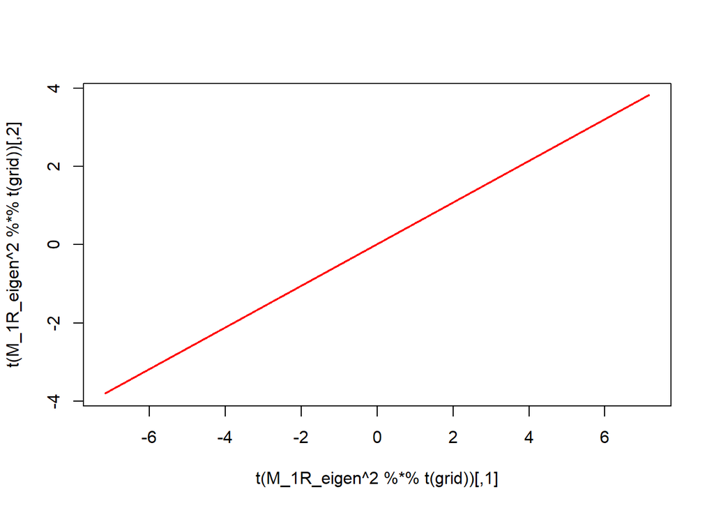

```r
plot(t(M_1R_eigen^2 %*% t(grid)), pch=20, cex=0.1, col = 2)
```

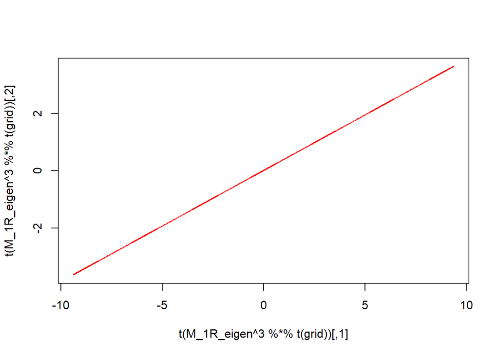

```r
plot(t(M_1R_eigen^3 %*% t(grid)), pch=20, cex=0.1, col = 2)
```

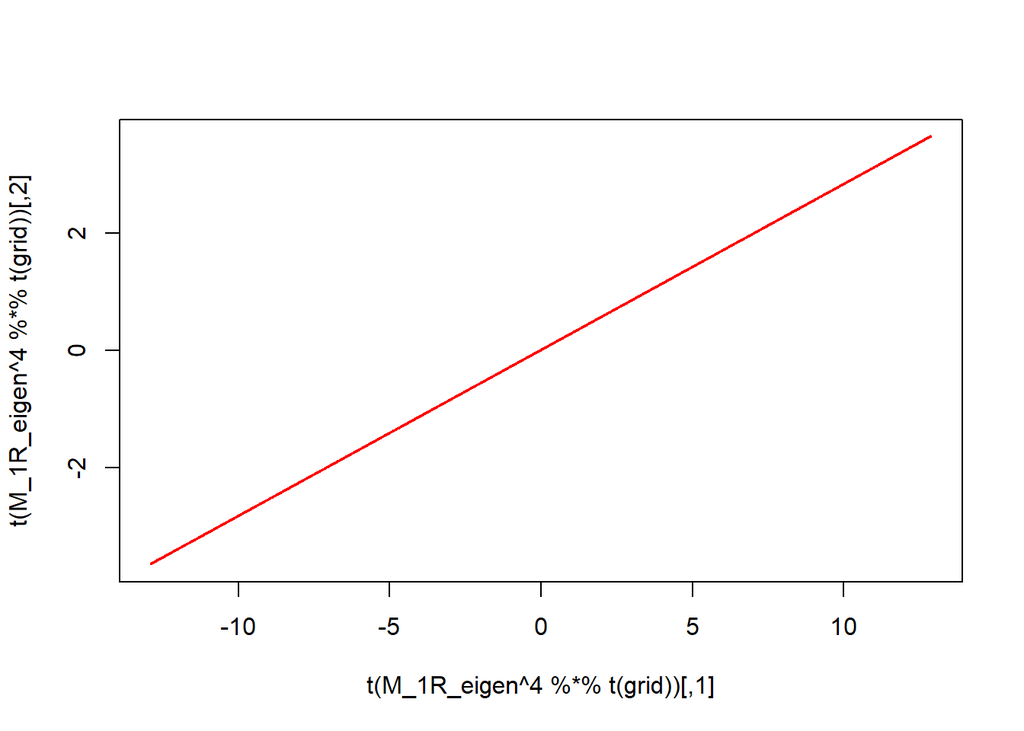

```r
plot(t(M_1R_eigen^4 %*% t(grid)), pch=20, cex=0.1, col = 2)
```

```r
plot(grid,pch=20,cex=0.1,xlim=c(-25,25),ylim=c(-25,25))
```

[output not shown]

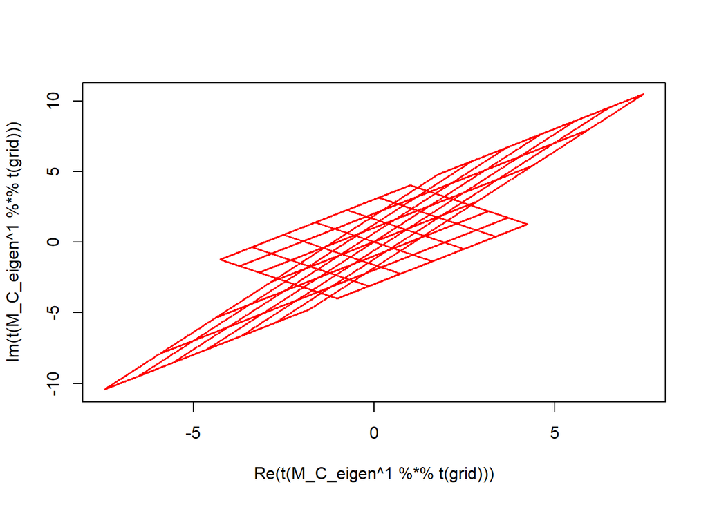

```r
plot(t(M_C_eigen^1 %*% t(grid)), pch=20, cex=0.1, col = 2)
```

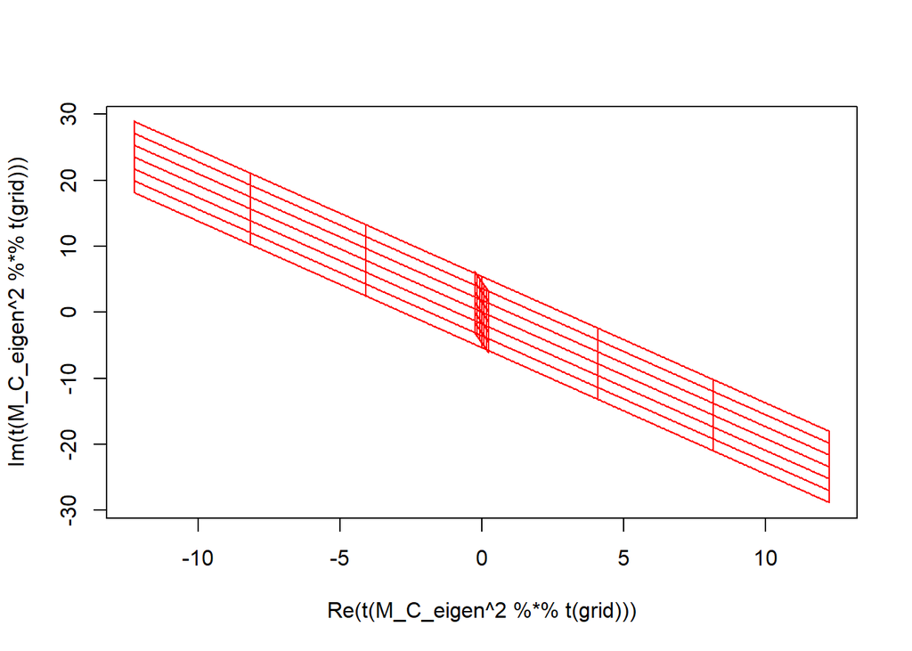

```r
plot(t(M_C_eigen^2 %*% t(grid)), pch=20, cex=0.1, col = 2)
```

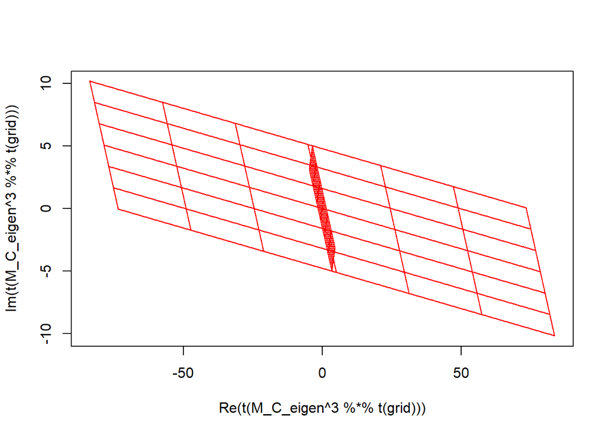

```r
plot(t(M_C_eigen^3 %*% t(grid)), pch=20, cex=0.1, col = 2)
```

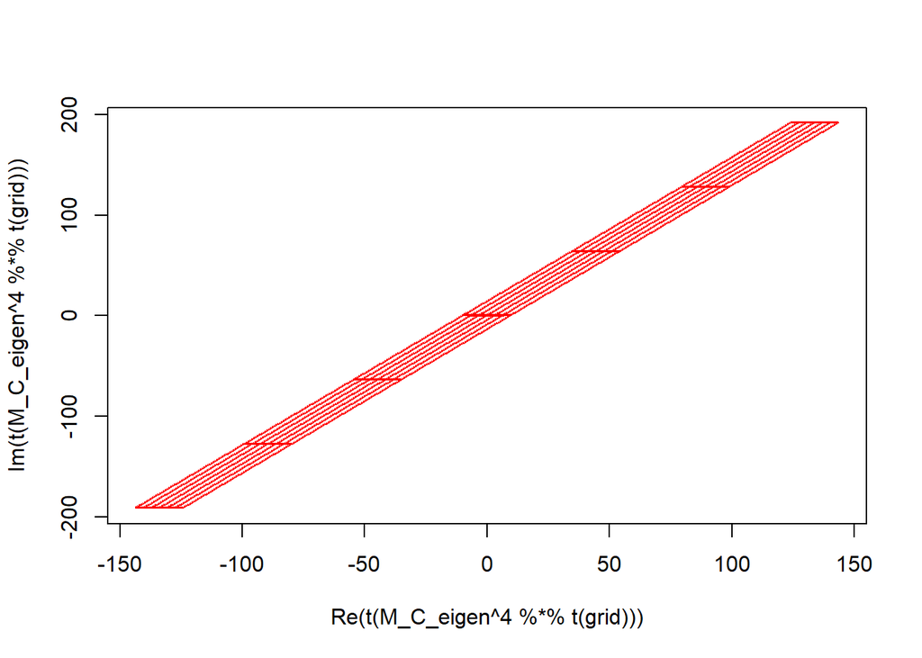

```r
plot(t(M_C_eigen^4 %*% t(grid)), pch=20, cex=0.1, col = 2)
```

# 3 Exercise 3

## 3.1 Exercise 3-1

行列Mを作成せよ。 また、Affine 変換を表す$3\times 3$行列を作成せよ。

作成した$3\times 3$行列により、(1,2)が動かないことを確認せよ。

$$(1, 0)\rightarrow(2, 3)\\
(0, 1)\rightarrow(3, 4)\\
M \times \begin{pmatrix}1, 0 \\ 0, 1\end{pmatrix} = \begin{pmatrix}2, 3 \\ 3, 4\end{pmatrix} \\
M = \begin{pmatrix}2, 3 \\ 3, 4\end{pmatrix} \\$$

$$M \times \begin{pmatrix}2 \\ 2\end{pmatrix} + \begin{pmatrix}u \\ v\end{pmatrix} = \begin{pmatrix}3 \\ 5\end{pmatrix} \\
u = -7, v = -9$$

```r
M <- matrix(c(2,3,3,4),2,byrow=T)
A <- matrix(c(2,3,-7,3,4,-9,0,0,1),3,byrow=T)
x <- c(1,2,1)
A %*% x
```

```
##      [,1]
## [1,]    1
## [2,]    2
## [3,]    1
```